# Analysis

- Report generated Sun Dec 28 21:18:39 2014

# 1 Linear models for Constructive Voice Behavior

## 1.1 Univariate regression

### 1.1.1 IVT univariate regression

|  | Estimate | Std. Error | t value | Pr(&gt \|t\|) |
| --- | --- | --- | --- | --- |
| (Intercept) | 6.0376 | 0.2671 | 22.61 | 0.0000 |
| Don.t.bypass.boss.upward | -0.1535 | 0.0658 | -2.34 | 0.0216 |

|  | Estimate | Std. Error | t value | Pr(&gt \|t\|) |
| --- | --- | --- | --- | --- |
| (Intercept) | 5.8471 | 0.2752 | 21.25 | 0.0000 |
| Presumed.Target.Identification | -0.1134 | 0.0743 | -1.53 | 0.1301 |

|  | Estimate | Std. Error | t value | Pr(&gt \|t\|) |
| --- | --- | --- | --- | --- |
| (Intercept) | 5.5237 | 0.3596 | 15.36 | 0.0000 |
| Don.t.embarass.boss.publicly | -0.0156 | 0.0749 | -0.21 | 0.8357 |

|  | Estimate | Std. Error | t value | Pr(&gt \|t\|) |
| --- | --- | --- | --- | --- |
| (Intercept) | 6.0014 | 0.2623 | 22.88 | 0.0000 |
| Negative.career.consequences.of.voice | -0.1599 | 0.0715 | -2.24 | 0.0276 |

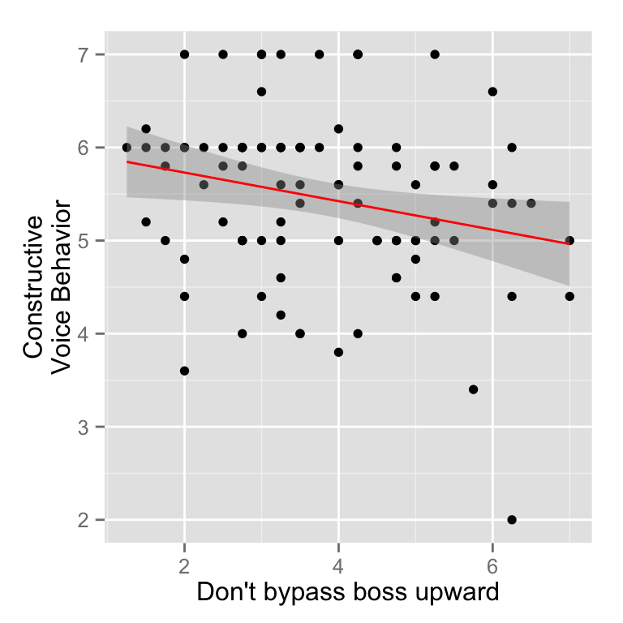

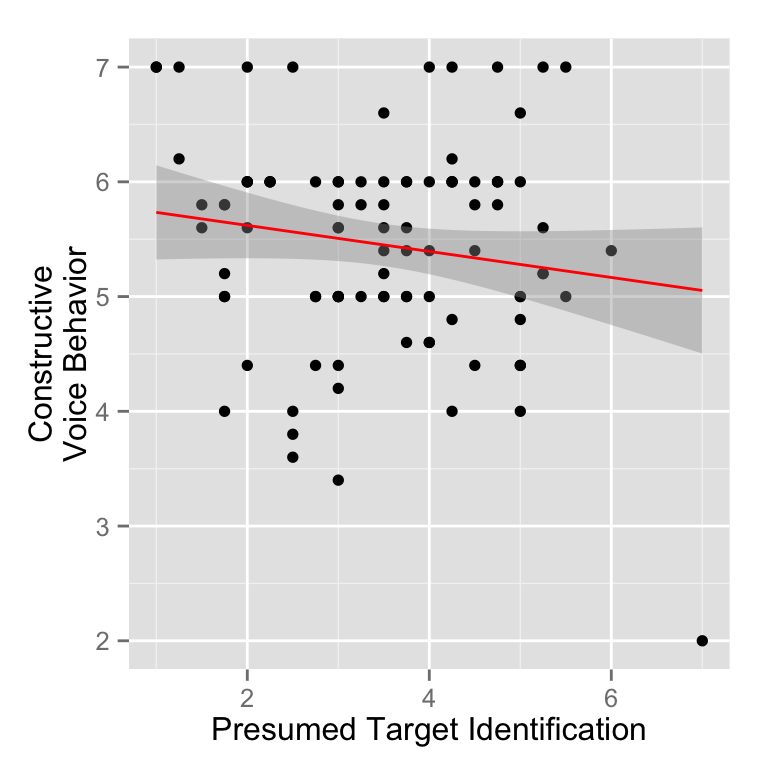

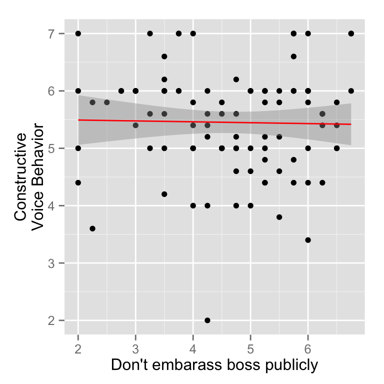

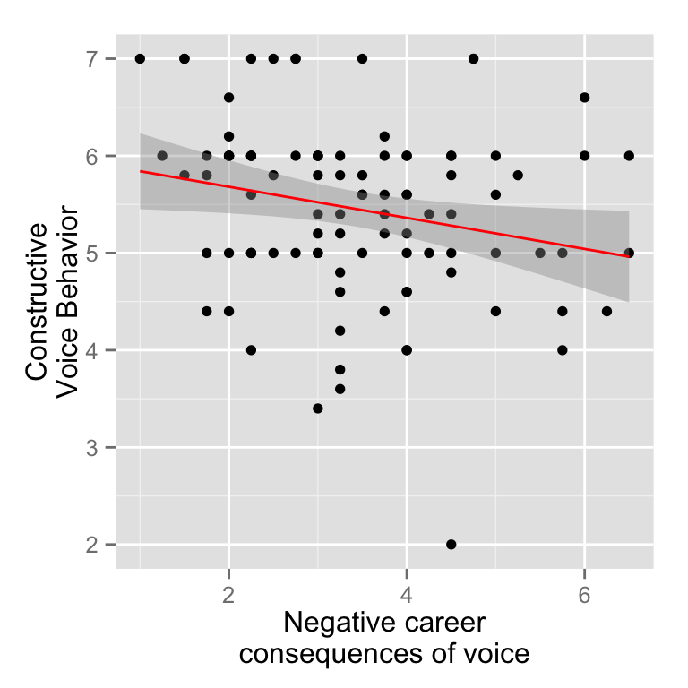

### 1.1.2 Key variables univariate regression

|  | Estimate | Std. Error | t value | Pr(&gt \|t\|) |
| --- | --- | --- | --- | --- |
| (Intercept) | 5.9316 | 0.2312 | 25.66 | 0.0000 |
| Power.Distance | -0.1937 | 0.0857 | -2.26 | 0.0260 |

|  | Estimate | Std. Error | t value | Pr(&gt \|t\|) |
| --- | --- | --- | --- | --- |
| (Intercept) | 7.6944 | 0.3706 | 20.76 | 0.0000 |
| Resistance.to.change | -0.6727 | 0.1086 | -6.19 | 0.0000 |

|  | Estimate | Std. Error | t value | Pr(&gt \|t\|) |
| --- | --- | --- | --- | --- |
| (Intercept) | 3.6337 | 0.5456 | 6.66 | 0.0000 |
| Openess.to.change | 0.2741 | 0.0812 | 3.38 | 0.0011 |

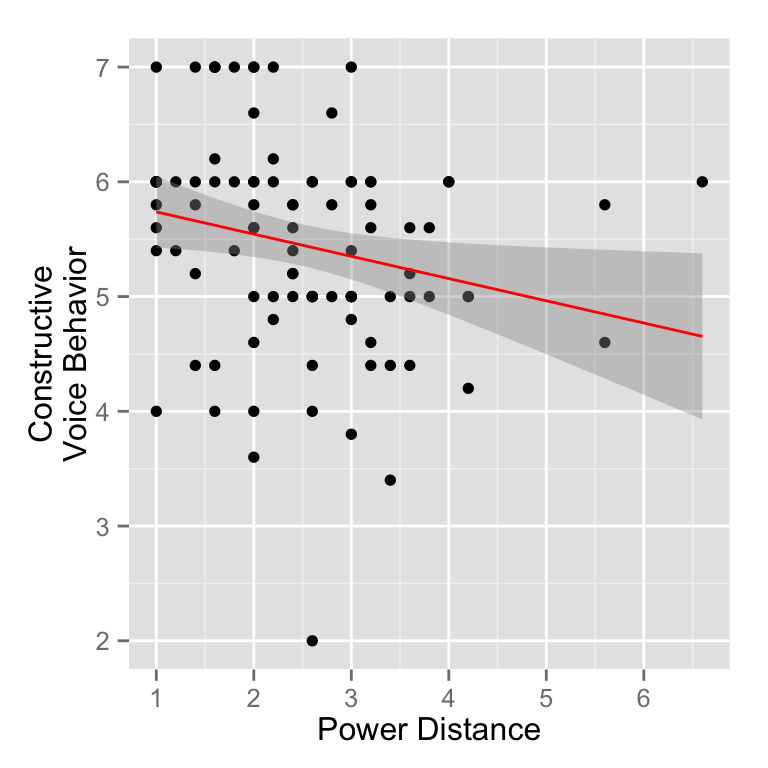

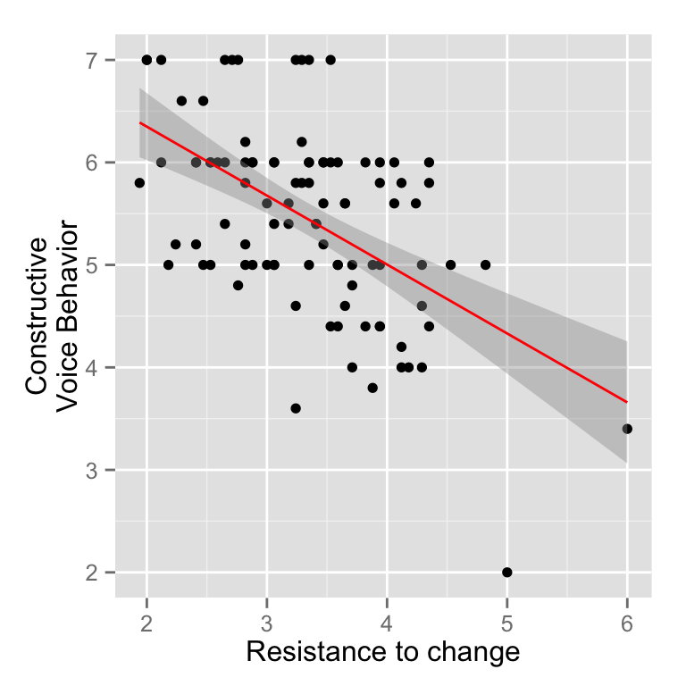

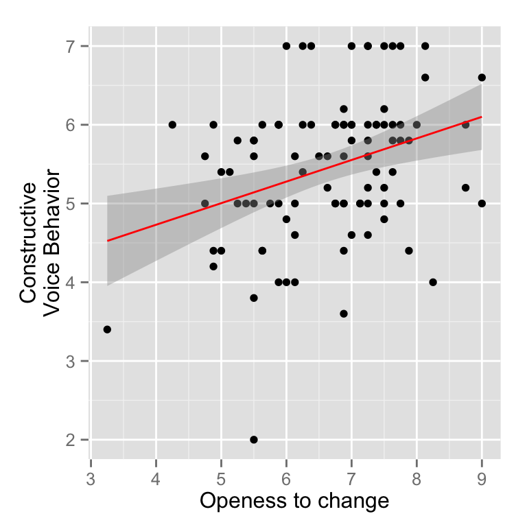

### 1.1.3 Demographics univariate regression

|  | Estimate | Std. Error | t value | Pr(&gt \|t\|) |
| --- | --- | --- | --- | --- |
| (Intercept) | 5.8267 | 0.2342 | 24.88 | 0.0000 |
| Age2 | -0.2405 | 0.2884 | -0.83 | 0.4066 |
| Age3 | -0.5117 | 0.2746 | -1.86 | 0.0655 |
| Age4 | -0.6882 | 0.3436 | -2.00 | 0.0481 |

|  | Estimate | Std. Error | t value | Pr(&gt \|t\|) |
| --- | --- | --- | --- | --- |
| (Intercept) | 5.5184 | 0.1317 | 41.91 | 0.0000 |
| Gender2 | -0.1350 | 0.1872 | -0.72 | 0.4724 |

|  | Estimate | Std. Error | t value | Pr(&gt \|t\|) |
| --- | --- | --- | --- | --- |
| (Intercept) | 5.1000 | 0.6577 | 7.75 | 0.0000 |
| Level.of.education2 | 0.7000 | 0.7353 | 0.95 | 0.3436 |
| Level.of.education3 | 0.2571 | 0.6808 | 0.38 | 0.7065 |
| Level.of.education4 | 0.3776 | 0.6710 | 0.56 | 0.5750 |
| Level.of.education5 | 0.2800 | 0.7205 | 0.39 | 0.6984 |

|  | Estimate | Std. Error | t value | Pr(&gt \|t\|) |
| --- | --- | --- | --- | --- |
| (Intercept) | 5.5920 | 0.1291 | 43.33 | 0.0000 |
| Manager2 | -0.2899 | 0.1854 | -1.56 | 0.1212 |

|  | Estimate | Std. Error | t value | Pr(&gt \|t\|) |
| --- | --- | --- | --- | --- |
| (Intercept) | 5.3920 | 0.1317 | 40.93 | 0.0000 |
| Duration.current.organisation2 | 0.1471 | 0.2347 | 0.63 | 0.5322 |
| Duration.current.organisation3 | 0.2413 | 0.2994 | 0.81 | 0.4223 |
| Duration.current.organisation4 | 0.1223 | 0.3759 | 0.33 | 0.7457 |
| Duration.current.organisation5 | -0.2720 | 0.4369 | -0.62 | 0.5351 |

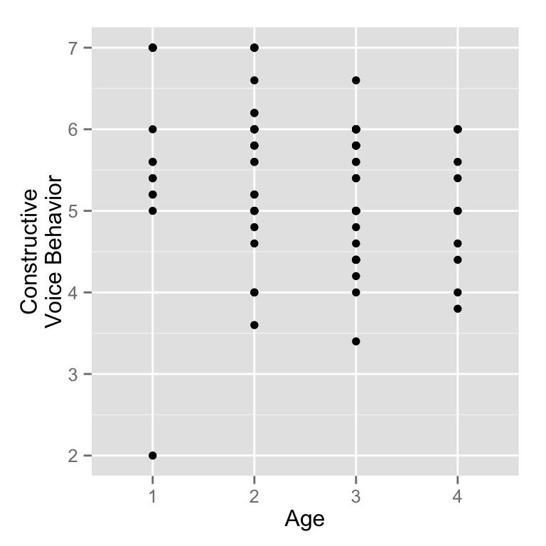

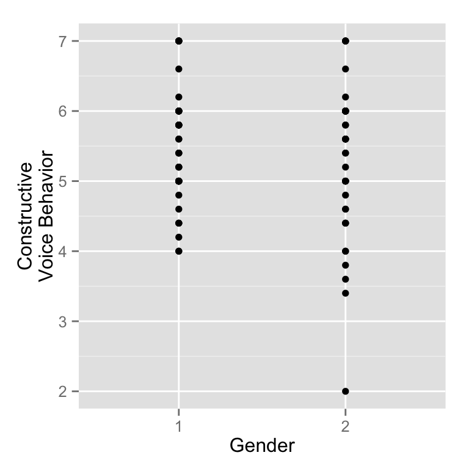

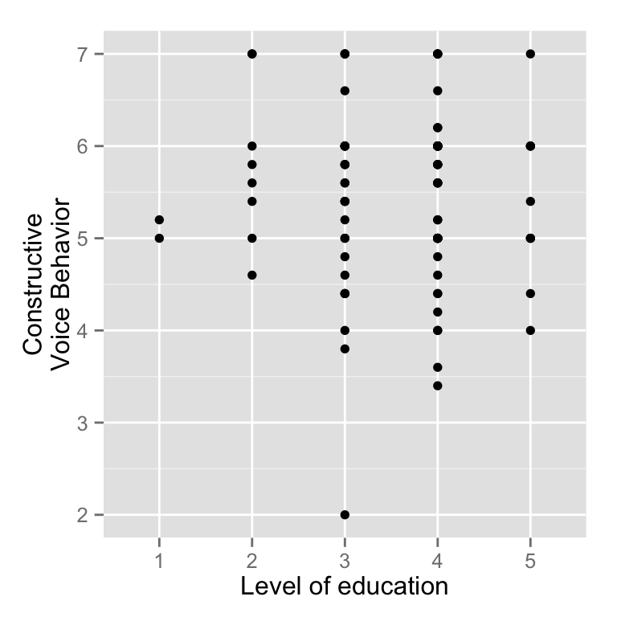

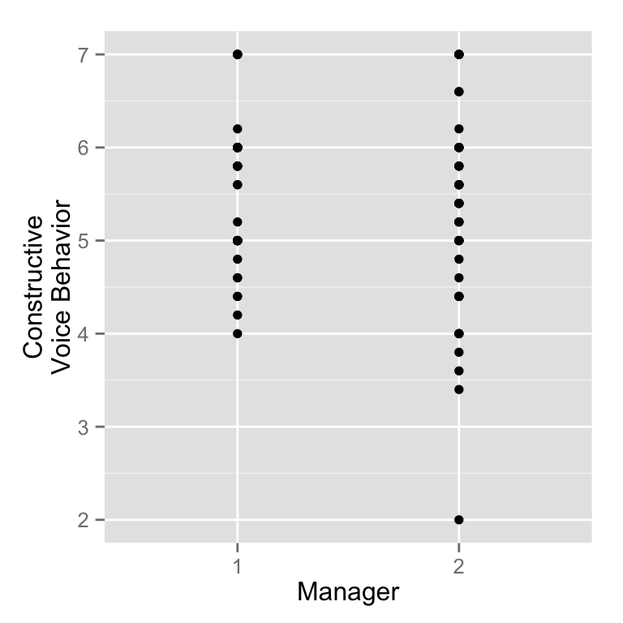

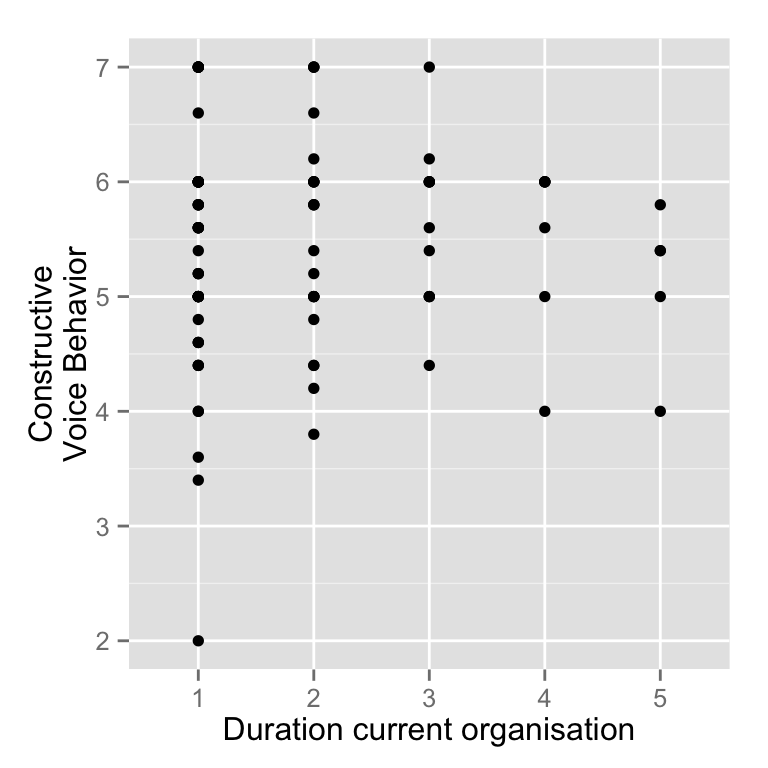

## 1.2 Multivariate regression

### 1.2.1 IVT multivariate regression

|  | Estimate | Std. Error | t value | Pr(&gt \|t\|) |
| --- | --- | --- | --- | --- |
| (Intercept) | 6.0233 | 0.4061 | 14.83 | 0.0000 |
| Don.t.bypass.boss.upward | -0.1340 | 0.0833 | -1.61 | 0.1112 |
| Presumed.Target.Identification | -0.0341 | 0.0863 | -0.39 | 0.6938 |
| Don.t.embarass.boss.publicly | 0.0800 | 0.0830 | 0.96 | 0.3372 |
| Negative.career.consequences.of.voice | -0.0908 | 0.0866 | -1.05 | 0.2968 |

### 1.2.2 Key variables multivariate regression

|  | Estimate | Std. Error | t value | Pr(&gt \|t\|) |
| --- | --- | --- | --- | --- |
| (Intercept) | 7.6990 | 0.8768 | 8.78 | 0.0000 |
| Power.Distance | -0.1665 | 0.0734 | -2.27 | 0.0256 |
| Resistance.to.change | -0.6299 | 0.1237 | -5.09 | 0.0000 |
| Openess.to.change | 0.0400 | 0.0831 | 0.48 | 0.6314 |

### 1.2.3 Demographics multivaraite regression

|  | Estimate | Std. Error | t value | Pr(&gt \|t\|) |
| --- | --- | --- | --- | --- |
| (Intercept) | 5.3083 | 0.7129 | 7.45 | 0.0000 |
| Age2 | -0.5509 | 0.3202 | -1.72 | 0.0890 |
| Age3 | -0.8824 | 0.3153 | -2.80 | 0.0064 |
| Age4 | -0.9740 | 0.3888 | -2.51 | 0.0142 |
| Gender2 | -0.1656 | 0.1942 | -0.85 | 0.3964 |
| Level.of.education2 | 1.1022 | 0.7523 | 1.47 | 0.1467 |
| Level.of.education3 | 0.8197 | 0.7241 | 1.13 | 0.2609 |
| Level.of.education4 | 0.8836 | 0.7098 | 1.24 | 0.2167 |
| Level.of.education5 | 1.0743 | 0.7790 | 1.38 | 0.1716 |
| Manager2 | -0.3733 | 0.2033 | -1.84 | 0.0700 |
| Duration.current.organisation2 | 0.3461 | 0.2481 | 1.40 | 0.1667 |
| Duration.current.organisation3 | 0.4510 | 0.3025 | 1.49 | 0.1398 |
| Duration.current.organisation4 | 0.4929 | 0.4173 | 1.18 | 0.2409 |
| Duration.current.organisation5 | 0.1375 | 0.4572 | 0.30 | 0.7643 |

## 1.3 Adjustment for key and demographic varaibles

### 1.3.1 IVT with main effects for key and demographic varaibles

Fit all as main effects and select with AIC algorithm. This finds a model that is a balance between simplicity and model fit. If the IVT variable is not in the final AIC model, then the other variables are associated with Constructive Voice Behavior, and any relationship with IVT is via other variables also being associated with IVT.

Don’t bypass boss upward: Initial model

|  | Estimate | Std. Error | t value | Pr(&gt \|t\|) |
| --- | --- | --- | --- | --- |
| (Intercept) | 7.4364 | 1.1663 | 6.38 | 0.0000 |
| Don.t.bypass.boss.upward | 0.0294 | 0.0715 | 0.41 | 0.6821 |
| Power.Distance | -0.1822 | 0.0856 | -2.13 | 0.0364 |
| Resistance.to.change | -0.5830 | 0.1421 | -4.10 | 0.0001 |
| Openess.to.change | 0.0678 | 0.0877 | 0.77 | 0.4418 |
| Age2 | -0.3345 | 0.2869 | -1.17 | 0.2472 |
| Age3 | -0.5175 | 0.2800 | -1.85 | 0.0683 |
| Age4 | -0.4668 | 0.3486 | -1.34 | 0.1843 |
| Gender2 | -0.0274 | 0.1758 | -0.16 | 0.8766 |
| Level.of.education2 | 0.3695 | 0.6605 | 0.56 | 0.5774 |
| Level.of.education3 | 0.3478 | 0.6335 | 0.55 | 0.5845 |
| Level.of.education4 | 0.3531 | 0.6211 | 0.57 | 0.5713 |
| Level.of.education5 | 0.3225 | 0.6847 | 0.47 | 0.6389 |
| Manager2 | -0.3978 | 0.1812 | -2.20 | 0.0311 |
| Duration.current.organisation2 | 0.0986 | 0.2187 | 0.45 | 0.6533 |
| Duration.current.organisation3 | 0.2859 | 0.2655 | 1.08 | 0.2847 |
| Duration.current.organisation4 | 0.5006 | 0.3602 | 1.39 | 0.1685 |
| Duration.current.organisation5 | -0.1182 | 0.3971 | -0.30 | 0.7666 |

Don’t bypass boss upward: Final AIC model

|  | Estimate | Std. Error | t value | Pr(&gt \|t\|) |
| --- | --- | --- | --- | --- |
| (Intercept) | 8.2574 | 0.3993 | 20.68 | 0.0000 |
| Power.Distance | -0.1879 | 0.0718 | -2.62 | 0.0103 |
| Resistance.to.change | -0.6553 | 0.1044 | -6.28 | 0.0000 |
| Manager2 | -0.3206 | 0.1531 | -2.09 | 0.0390 |

Presumed Target Identification: Initial model

|  | Estimate | Std. Error | t value | Pr(&gt \|t\|) |
| --- | --- | --- | --- | --- |
| (Intercept) | 7.5250 | 1.1910 | 6.32 | 0.0000 |
| Presumed.Target.Identification | -0.0254 | 0.0732 | -0.35 | 0.7295 |
| Power.Distance | -0.1662 | 0.0815 | -2.04 | 0.0447 |
| Resistance.to.change | -0.5597 | 0.1349 | -4.15 | 0.0001 |
| Openess.to.change | 0.0692 | 0.0876 | 0.79 | 0.4318 |
| Age2 | -0.3720 | 0.2837 | -1.31 | 0.1936 |
| Age3 | -0.5435 | 0.2802 | -1.94 | 0.0560 |
| Age4 | -0.4794 | 0.3513 | -1.36 | 0.1763 |
| Gender2 | -0.0636 | 0.1747 | -0.36 | 0.7167 |
| Level.of.education2 | 0.3774 | 0.6598 | 0.57 | 0.5689 |
| Level.of.education3 | 0.3714 | 0.6304 | 0.59 | 0.5574 |
| Level.of.education4 | 0.3614 | 0.6208 | 0.58 | 0.5621 |
| Level.of.education5 | 0.3349 | 0.6834 | 0.49 | 0.6255 |
| Manager2 | -0.3596 | 0.1880 | -1.91 | 0.0595 |
| Duration.current.organisation2 | 0.0846 | 0.2185 | 0.39 | 0.6996 |
| Duration.current.organisation3 | 0.2828 | 0.2660 | 1.06 | 0.2909 |
| Duration.current.organisation4 | 0.4790 | 0.3610 | 1.33 | 0.1884 |
| Duration.current.organisation5 | -0.1095 | 0.3988 | -0.27 | 0.7844 |

Presumed Target Identification: Final AIC model

|  | Estimate | Std. Error | t value | Pr(&gt \|t\|) |
| --- | --- | --- | --- | --- |
| (Intercept) | 8.2574 | 0.3993 | 20.68 | 0.0000 |
| Power.Distance | -0.1879 | 0.0718 | -2.62 | 0.0103 |
| Resistance.to.change | -0.6553 | 0.1044 | -6.28 | 0.0000 |
| Manager2 | -0.3206 | 0.1531 | -2.09 | 0.0390 |

Don’t embarass boss publicly: Initial model

|  | Estimate | Std. Error | t value | Pr(&gt \|t\|) |
| --- | --- | --- | --- | --- |
| (Intercept) | 6.7991 | 1.1869 | 5.73 | 0.0000 |
| Don.t.embarass.boss.publicly | 0.1436 | 0.0736 | 1.95 | 0.0546 |
| Power.Distance | -0.2266 | 0.0839 | -2.70 | 0.0084 |
| Resistance.to.change | -0.5978 | 0.1325 | -4.51 | 0.0000 |
| Openess.to.change | 0.0770 | 0.0857 | 0.90 | 0.3714 |
| Age2 | -0.2328 | 0.2821 | -0.83 | 0.4117 |
| Age3 | -0.4211 | 0.2776 | -1.52 | 0.1332 |
| Age4 | -0.4659 | 0.3408 | -1.37 | 0.1755 |
| Gender2 | -0.0008 | 0.1667 | -0.00 | 0.9964 |
| Level.of.education2 | 0.4224 | 0.6440 | 0.66 | 0.5138 |
| Level.of.education3 | 0.3795 | 0.6161 | 0.62 | 0.5397 |
| Level.of.education4 | 0.4129 | 0.6072 | 0.68 | 0.4986 |
| Level.of.education5 | 0.4189 | 0.6687 | 0.63 | 0.5328 |
| Manager2 | -0.3828 | 0.1730 | -2.21 | 0.0298 |
| Duration.current.organisation2 | 0.1473 | 0.2149 | 0.69 | 0.4951 |
| Duration.current.organisation3 | 0.3656 | 0.2624 | 1.39 | 0.1675 |
| Duration.current.organisation4 | 0.6262 | 0.3582 | 1.75 | 0.0843 |
| Duration.current.organisation5 | 0.0203 | 0.3950 | 0.05 | 0.9591 |

Don’t embarass boss publicly: Final AIC model

|  | Estimate | Std. Error | t value | Pr(&gt \|t\|) |
| --- | --- | --- | --- | --- |
| (Intercept) | 7.9108 | 0.4273 | 18.51 | 0.0000 |
| Don.t.embarass.boss.publicly | 0.1318 | 0.0642 | 2.05 | 0.0428 |
| Power.Distance | -0.2362 | 0.0744 | -3.17 | 0.0020 |
| Resistance.to.change | -0.6941 | 0.1044 | -6.65 | 0.0000 |
| Manager2 | -0.3516 | 0.1513 | -2.32 | 0.0224 |

Negative career consequences of voice: Initial model

|  | Estimate | Std. Error | t value | Pr(&gt \|t\|) |
| --- | --- | --- | --- | --- |
| (Intercept) | 7.4289 | 1.1659 | 6.37 | 0.0000 |
| Negative.career.consequences.of.voice | -0.0361 | 0.0723 | -0.50 | 0.6187 |
| Power.Distance | -0.1588 | 0.0837 | -1.90 | 0.0615 |
| Resistance.to.change | -0.5500 | 0.1372 | -4.01 | 0.0001 |
| Openess.to.change | 0.0775 | 0.0888 | 0.87 | 0.3859 |
| Age2 | -0.3801 | 0.2841 | -1.34 | 0.1848 |
| Age3 | -0.5308 | 0.2778 | -1.91 | 0.0596 |
| Age4 | -0.4617 | 0.3484 | -1.33 | 0.1889 |
| Gender2 | -0.0637 | 0.1715 | -0.37 | 0.7115 |
| Level.of.education2 | 0.3991 | 0.6583 | 0.61 | 0.5460 |
| Level.of.education3 | 0.3950 | 0.6311 | 0.63 | 0.5332 |
| Level.of.education4 | 0.3824 | 0.6212 | 0.62 | 0.5399 |
| Level.of.education5 | 0.3673 | 0.6840 | 0.54 | 0.5927 |
| Manager2 | -0.3632 | 0.1806 | -2.01 | 0.0478 |
| Duration.current.organisation2 | 0.0853 | 0.2179 | 0.39 | 0.6965 |
| Duration.current.organisation3 | 0.2836 | 0.2654 | 1.07 | 0.2886 |
| Duration.current.organisation4 | 0.4716 | 0.3611 | 1.31 | 0.1954 |
| Duration.current.organisation5 | -0.0961 | 0.4002 | -0.24 | 0.8109 |

Negative career consequences of voice: Final AIC model

|  | Estimate | Std. Error | t value | Pr(&gt \|t\|) |
| --- | --- | --- | --- | --- |
| (Intercept) | 8.2574 | 0.3993 | 20.68 | 0.0000 |
| Power.Distance | -0.1879 | 0.0718 | -2.62 | 0.0103 |
| Resistance.to.change | -0.6553 | 0.1044 | -6.28 | 0.0000 |
| Manager2 | -0.3206 | 0.1531 | -2.09 | 0.0390 |

### 1.3.2 IVT with main and interaction effects for key and demographic varaibles

Don’t bypass boss upward: Initial model

|  | Estimate | Std. Error | t value | Pr(&gt \|t\|) |
| --- | --- | --- | --- | --- |
| (Intercept) | 6.3086 | 4.5328 | 1.39 | 0.1689 |
| Don.t.bypass.boss.upward | 0.3957 | 1.0977 | 0.36 | 0.7197 |
| Power.Distance | -0.0963 | 0.3199 | -0.30 | 0.7643 |
| Resistance.to.change | -0.5487 | 0.5067 | -1.08 | 0.2830 |
| Openess.to.change | 0.2014 | 0.2975 | 0.68 | 0.5010 |
| Age2 | -2.3270 | 0.9252 | -2.52 | 0.0145 |
| Age3 | -1.8465 | 0.9793 | -1.89 | 0.0640 |
| Age4 | -2.0591 | 1.6812 | -1.22 | 0.2252 |
| Gender2 | -0.0645 | 0.5784 | -0.11 | 0.9115 |
| Level.of.education2 | -0.0819 | 3.6034 | -0.02 | 0.9819 |
| Level.of.education3 | 2.1070 | 3.3392 | 0.63 | 0.5303 |
| Level.of.education4 | 1.1813 | 3.2796 | 0.36 | 0.7199 |
| Level.of.education5 | 0.9058 | 3.4694 | 0.26 | 0.7949 |
| Manager2 | -0.1467 | 0.5674 | -0.26 | 0.7968 |
| Duration.current.organisation2 | -0.4354 | 0.7365 | -0.59 | 0.5565 |
| Duration.current.organisation3 | 1.6478 | 0.8139 | 2.02 | 0.0471 |
| Duration.current.organisation4 | 1.1512 | 2.3775 | 0.48 | 0.6299 |
| Duration.current.organisation5 | -1.7605 | 1.6014 | -1.10 | 0.2758 |
| Don.t.bypass.boss.upward:Power.Distance | -0.0325 | 0.0785 | -0.41 | 0.6799 |
| Don.t.bypass.boss.upward:Resistance.to.change | -0.0180 | 0.1187 | -0.15 | 0.8802 |
| Don.t.bypass.boss.upward:Openess.to.change | -0.0432 | 0.0716 | -0.60 | 0.5487 |
| Don.t.bypass.boss.upward:Age2 | 0.5371 | 0.2430 | 2.21 | 0.0307 |
| Don.t.bypass.boss.upward:Age3 | 0.3681 | 0.2398 | 1.54 | 0.1298 |
| Don.t.bypass.boss.upward:Age4 | 0.3721 | 0.3521 | 1.06 | 0.2946 |
| Don.t.bypass.boss.upward:Gender2 | 0.0181 | 0.1588 | 0.11 | 0.9095 |
| Don.t.bypass.boss.upward:Level.of.education2 | 0.1720 | 0.9094 | 0.19 | 0.8506 |
| Don.t.bypass.boss.upward:Level.of.education3 | -0.3874 | 0.8380 | -0.46 | 0.6455 |
| Don.t.bypass.boss.upward:Level.of.education4 | -0.2054 | 0.8133 | -0.25 | 0.8015 |
| Don.t.bypass.boss.upward:Level.of.education5 | -0.1141 | 0.8633 | -0.13 | 0.8953 |
| Don.t.bypass.boss.upward:Manager2 | -0.0621 | 0.1477 | -0.42 | 0.6756 |
| Don.t.bypass.boss.upward:Duration.current.organisation2 | 0.1607 | 0.1923 | 0.84 | 0.4065 |
| Don.t.bypass.boss.upward:Duration.current.organisation3 | -0.3259 | 0.2135 | -1.53 | 0.1318 |
| Don.t.bypass.boss.upward:Duration.current.organisation4 | -0.1481 | 0.5993 | -0.25 | 0.8056 |
| Don.t.bypass.boss.upward:Duration.current.organisation5 | 0.3805 | 0.3731 | 1.02 | 0.3117 |

Don’t bypass boss upward: Final AIC model

|  | Estimate | Std. Error | t value | Pr(&gt \|t\|) |
| --- | --- | --- | --- | --- |
| (Intercept) | 8.2574 | 0.3993 | 20.68 | 0.0000 |
| Power.Distance | -0.1879 | 0.0718 | -2.62 | 0.0103 |
| Resistance.to.change | -0.6553 | 0.1044 | -6.28 | 0.0000 |
| Manager2 | -0.3206 | 0.1531 | -2.09 | 0.0390 |

Presumed Target Identification: Initial model

|  | Estimate | Std. Error | t value | Pr(&gt \|t\|) |
| --- | --- | --- | --- | --- |
| (Intercept) | 6.8546 | 4.2450 | 1.61 | 0.1114 |
| Presumed.Target.Identification | -0.0089 | 1.1255 | -0.01 | 0.9937 |
| Power.Distance | -0.3224 | 0.3330 | -0.97 | 0.3368 |
| Resistance.to.change | 0.1065 | 0.4570 | 0.23 | 0.8165 |
| Openess.to.change | 0.0565 | 0.3336 | 0.17 | 0.8659 |
| Age2 | -1.9330 | 0.8102 | -2.39 | 0.0201 |
| Age3 | -1.6267 | 1.0728 | -1.52 | 0.1344 |
| Age4 | -2.4106 | 1.2125 | -1.99 | 0.0512 |
| Gender2 | -0.1822 | 0.6595 | -0.28 | 0.7832 |
| Level.of.education2 | 1.2871 | 2.6216 | 0.49 | 0.6252 |
| Level.of.education3 | 1.2340 | 2.4292 | 0.51 | 0.6132 |
| Level.of.education4 | 0.3425 | 2.4143 | 0.14 | 0.8876 |
| Level.of.education5 | -1.0797 | 2.6745 | -0.40 | 0.6878 |
| Manager2 | -0.7241 | 0.6681 | -1.08 | 0.2825 |
| Duration.current.organisation2 | -0.1569 | 0.7439 | -0.21 | 0.8337 |
| Duration.current.organisation3 | 0.8865 | 1.0953 | 0.81 | 0.4213 |
| Duration.current.organisation4 | 0.4725 | 1.2521 | 0.38 | 0.7072 |
| Duration.current.organisation5 | 0.0379 | 3.8347 | 0.01 | 0.9921 |
| Presumed.Target.Identification:Power.Distance | 0.0370 | 0.0865 | 0.43 | 0.6707 |
| Presumed.Target.Identification:Resistance.to.change | -0.1419 | 0.1165 | -1.22 | 0.2276 |
| Presumed.Target.Identification:Openess.to.change | 0.0099 | 0.0945 | 0.10 | 0.9170 |
| Presumed.Target.Identification:Age2 | 0.3869 | 0.2137 | 1.81 | 0.0751 |
| Presumed.Target.Identification:Age3 | 0.2566 | 0.2665 | 0.96 | 0.3394 |
| Presumed.Target.Identification:Age4 | 0.4498 | 0.3098 | 1.45 | 0.1514 |
| Presumed.Target.Identification:Gender2 | 0.0914 | 0.1855 | 0.49 | 0.6239 |
| Presumed.Target.Identification:Level.of.education2 | -0.2568 | 0.6483 | -0.40 | 0.6934 |
| Presumed.Target.Identification:Level.of.education3 | -0.2060 | 0.5753 | -0.36 | 0.7214 |
| Presumed.Target.Identification:Level.of.education4 | 0.0041 | 0.5865 | 0.01 | 0.9944 |
| Presumed.Target.Identification:Level.of.education5 | 0.4368 | 0.6675 | 0.65 | 0.5153 |
| Presumed.Target.Identification:Manager2 | 0.1010 | 0.1853 | 0.54 | 0.5878 |
| Presumed.Target.Identification:Duration.current.organisation2 | 0.0863 | 0.1950 | 0.44 | 0.6596 |
| Presumed.Target.Identification:Duration.current.organisation3 | -0.1460 | 0.3112 | -0.47 | 0.6406 |
| Presumed.Target.Identification:Duration.current.organisation4 | 0.0580 | 0.3659 | 0.16 | 0.8745 |
| Presumed.Target.Identification:Duration.current.organisation5 | -0.0156 | 0.9143 | -0.02 | 0.9865 |

Presumed Target Identification: Final AIC model

|  | Estimate | Std. Error | t value | Pr(&gt \|t\|) |
| --- | --- | --- | --- | --- |
| (Intercept) | 9.6620 | 0.5780 | 16.72 | 0.0000 |
| Presumed.Target.Identification | -0.3444 | 0.1204 | -2.86 | 0.0053 |
| Power.Distance | -0.1658 | 0.0733 | -2.26 | 0.0263 |
| Resistance.to.change | -0.5910 | 0.1045 | -5.65 | 0.0000 |
| Age2 | -1.9253 | 0.6333 | -3.04 | 0.0031 |
| Age3 | -1.8789 | 0.6479 | -2.90 | 0.0047 |
| Age4 | -2.1712 | 0.8362 | -2.60 | 0.0111 |
| Manager2 | -0.3012 | 0.1670 | -1.80 | 0.0749 |
| Presumed.Target.Identification:Age2 | 0.4312 | 0.1592 | 2.71 | 0.0081 |
| Presumed.Target.Identification:Age3 | 0.3657 | 0.1614 | 2.27 | 0.0259 |
| Presumed.Target.Identification:Age4 | 0.4680 | 0.2101 | 2.23 | 0.0285 |

Don’t embarass boss publicly: Initial model

|  | Estimate | Std. Error | t value | Pr(&gt \|t\|) |
| --- | --- | --- | --- | --- |
| (Intercept) | 19.3841 | 14.3713 | 1.35 | 0.1822 |
| Don.t.embarass.boss.publicly | -2.4410 | 2.8000 | -0.87 | 0.3866 |
| Power.Distance | -0.8067 | 0.4183 | -1.93 | 0.0583 |
| Resistance.to.change | -2.0690 | 0.7390 | -2.80 | 0.0068 |
| Openess.to.change | -0.1359 | 0.4364 | -0.31 | 0.7565 |
| Age2 | -1.3291 | 1.3108 | -1.01 | 0.3145 |
| Age3 | -0.1325 | 1.3319 | -0.10 | 0.9211 |
| Age4 | -1.3210 | 1.8946 | -0.70 | 0.4882 |
| Gender2 | -0.6641 | 0.7170 | -0.93 | 0.3579 |
| Level.of.education2 | -5.3055 | 13.0353 | -0.41 | 0.6854 |
| Level.of.education3 | -5.4528 | 12.9704 | -0.42 | 0.6756 |
| Level.of.education4 | -4.6013 | 13.0348 | -0.35 | 0.7253 |
| Level.of.education5 | -7.5040 | 12.9926 | -0.58 | 0.5656 |
| Manager2 | 0.2276 | 0.7965 | 0.29 | 0.7760 |
| Duration.current.organisation2 | 0.9399 | 0.9078 | 1.04 | 0.3044 |
| Duration.current.organisation3 | 1.8768 | 1.3206 | 1.42 | 0.1602 |
| Duration.current.organisation4 | 3.3367 | 1.6843 | 1.98 | 0.0520 |
| Duration.current.organisation5 | 0.8933 | 2.2747 | 0.39 | 0.6959 |
| Don.t.embarass.boss.publicly:Power.Distance | 0.1302 | 0.0927 | 1.40 | 0.1651 |
| Don.t.embarass.boss.publicly:Resistance.to.change | 0.2967 | 0.1460 | 2.03 | 0.0463 |
| Don.t.embarass.boss.publicly:Openess.to.change | 0.0627 | 0.0934 | 0.67 | 0.5048 |
| Don.t.embarass.boss.publicly:Age2 | 0.1739 | 0.2774 | 0.63 | 0.5329 |
| Don.t.embarass.boss.publicly:Age3 | -0.1053 | 0.2665 | -0.40 | 0.6942 |
| Don.t.embarass.boss.publicly:Age4 | 0.1123 | 0.3636 | 0.31 | 0.7585 |
| Don.t.embarass.boss.publicly:Gender2 | 0.1510 | 0.1514 | 1.00 | 0.3225 |
| Don.t.embarass.boss.publicly:Level.of.education2 | 1.0101 | 2.4689 | 0.41 | 0.6838 |
| Don.t.embarass.boss.publicly:Level.of.education3 | 1.1198 | 2.4643 | 0.45 | 0.6511 |
| Don.t.embarass.boss.publicly:Level.of.education4 | 0.9238 | 2.4855 | 0.37 | 0.7114 |
| Don.t.embarass.boss.publicly:Level.of.education5 | 1.5565 | 2.4753 | 0.63 | 0.5317 |
| Don.t.embarass.boss.publicly:Manager2 | -0.1543 | 0.1739 | -0.89 | 0.3784 |
| Don.t.embarass.boss.publicly:Duration.current.organisation2 | -0.1653 | 0.1832 | -0.90 | 0.3704 |
| Don.t.embarass.boss.publicly:Duration.current.organisation3 | -0.3215 | 0.2977 | -1.08 | 0.2842 |
| Don.t.embarass.boss.publicly:Duration.current.organisation4 | -0.5968 | 0.3553 | -1.68 | 0.0979 |
| Don.t.embarass.boss.publicly:Duration.current.organisation5 | -0.2341 | 0.5152 | -0.45 | 0.6511 |

Don’t embarass boss publicly: Final AIC model

|  | Estimate | Std. Error | t value | Pr(&gt \|t\|) |
| --- | --- | --- | --- | --- |
| (Intercept) | 7.9108 | 0.4273 | 18.51 | 0.0000 |
| Don.t.embarass.boss.publicly | 0.1318 | 0.0642 | 2.05 | 0.0428 |
| Power.Distance | -0.2362 | 0.0744 | -3.17 | 0.0020 |
| Resistance.to.change | -0.6941 | 0.1044 | -6.65 | 0.0000 |
| Manager2 | -0.3516 | 0.1513 | -2.32 | 0.0224 |

Negative career consequences of voice: Initial model

|  | Estimate | Std. Error | t value | Pr(&gt \|t\|) |
| --- | --- | --- | --- | --- |
| (Intercept) | 8.1544 | 5.9010 | 1.38 | 0.1719 |
| Negative.career.consequences.of.voice | -0.1887 | 1.6353 | -0.12 | 0.9085 |
| Power.Distance | -0.3611 | 0.3023 | -1.19 | 0.2368 |
| Resistance.to.change | -0.0392 | 0.5664 | -0.07 | 0.9450 |
| Openess.to.change | 0.0913 | 0.3375 | 0.27 | 0.7877 |
| Age2 | -0.2925 | 1.1971 | -0.24 | 0.8078 |
| Age3 | -1.2856 | 1.2848 | -1.00 | 0.3208 |
| Age4 | -0.8661 | 1.5030 | -0.58 | 0.5665 |
| Gender2 | -0.1090 | 0.6201 | -0.18 | 0.8611 |
| Level.of.education2 | -0.6709 | 4.7437 | -0.14 | 0.8880 |
| Level.of.education3 | -0.7360 | 4.8442 | -0.15 | 0.8797 |
| Level.of.education4 | -1.5048 | 4.8304 | -0.31 | 0.7564 |
| Level.of.education5 | -0.8411 | 4.9227 | -0.17 | 0.8649 |
| Manager2 | -0.3012 | 0.6193 | -0.49 | 0.6284 |
| Duration.current.organisation2 | -0.2462 | 0.7725 | -0.32 | 0.7510 |
| Duration.current.organisation3 | 0.1619 | 0.8703 | 0.19 | 0.8530 |
| Duration.current.organisation4 | -0.6505 | 1.5017 | -0.43 | 0.6663 |
| Duration.current.organisation5 | 1.8098 | 2.3845 | 0.76 | 0.4507 |
| Negative.career.consequences.of.voice:Power.Distance | 0.0438 | 0.0761 | 0.58 | 0.5673 |
| Negative.career.consequences.of.voice:Resistance.to.change | -0.1231 | 0.1497 | -0.82 | 0.4139 |
| Negative.career.consequences.of.voice:Openess.to.change | -0.0078 | 0.0963 | -0.08 | 0.9360 |
| Negative.career.consequences.of.voice:Age2 | -0.0626 | 0.3508 | -0.18 | 0.8590 |
| Negative.career.consequences.of.voice:Age3 | 0.1871 | 0.3527 | 0.53 | 0.5975 |
| Negative.career.consequences.of.voice:Age4 | 0.1137 | 0.4056 | 0.28 | 0.7801 |
| Negative.career.consequences.of.voice:Gender2 | 0.0239 | 0.1816 | 0.13 | 0.8956 |
| Negative.career.consequences.of.voice:Level.of.education2 | 0.3068 | 1.3286 | 0.23 | 0.8181 |
| Negative.career.consequences.of.voice:Level.of.education3 | 0.2837 | 1.3573 | 0.21 | 0.8351 |
| Negative.career.consequences.of.voice:Level.of.education4 | 0.4960 | 1.3621 | 0.36 | 0.7170 |
| Negative.career.consequences.of.voice:Level.of.education5 | 0.3177 | 1.3940 | 0.23 | 0.8205 |
| Negative.career.consequences.of.voice:Manager2 | -0.0451 | 0.1782 | -0.25 | 0.8008 |
| Negative.career.consequences.of.voice:Duration.current.organisation2 | 0.0923 | 0.2266 | 0.41 | 0.6852 |
| Negative.career.consequences.of.voice:Duration.current.organisation3 | 0.0264 | 0.2411 | 0.11 | 0.9132 |
| Negative.career.consequences.of.voice:Duration.current.organisation4 | 0.3152 | 0.4292 | 0.73 | 0.4655 |
| Negative.career.consequences.of.voice:Duration.current.organisation5 | -0.4079 | 0.5126 | -0.80 | 0.4291 |

Negative career consequences of voice: Final AIC model

|  | Estimate | Std. Error | t value | Pr(&gt \|t\|) |
| --- | --- | --- | --- | --- |
| (Intercept) | 8.2574 | 0.3993 | 20.68 | 0.0000 |
| Power.Distance | -0.1879 | 0.0718 | -2.62 | 0.0103 |
| Resistance.to.change | -0.6553 | 0.1044 | -6.28 | 0.0000 |
| Manager2 | -0.3206 | 0.1531 | -2.09 | 0.0390 |

### 1.3.3 Key variables with main effects for IVT and demographic varaibles

Power Distance: Initial model

|  | Estimate | Std. Error | t value | Pr(&gt \|t\|) |
| --- | --- | --- | --- | --- |
| (Intercept) | 5.8771 | 0.9017 | 6.52 | 0.0000 |
| Power.Distance | -0.1737 | 0.1012 | -1.72 | 0.0901 |
| Don.t.bypass.boss.upward | -0.1049 | 0.0874 | -1.20 | 0.2337 |
| Presumed.Target.Identification | -0.0544 | 0.0929 | -0.59 | 0.5596 |
| Don.t.embarass.boss.publicly | 0.1231 | 0.0916 | 1.34 | 0.1827 |
| Negative.career.consequences.of.voice | -0.0294 | 0.0906 | -0.32 | 0.7465 |
| Age2 | -0.4433 | 0.3314 | -1.34 | 0.1849 |
| Age3 | -0.7628 | 0.3191 | -2.39 | 0.0192 |
| Age4 | -0.7911 | 0.3985 | -1.99 | 0.0506 |
| Gender2 | -0.2311 | 0.2008 | -1.15 | 0.2534 |
| Level.of.education2 | 1.0015 | 0.7467 | 1.34 | 0.1837 |
| Level.of.education3 | 0.7160 | 0.7209 | 0.99 | 0.3236 |
| Level.of.education4 | 0.7218 | 0.7086 | 1.02 | 0.3115 |
| Level.of.education5 | 0.9677 | 0.7779 | 1.24 | 0.2172 |
| Manager2 | -0.2845 | 0.2174 | -1.31 | 0.1946 |
| Duration.current.organisation2 | 0.2674 | 0.2510 | 1.07 | 0.2900 |
| Duration.current.organisation3 | 0.4427 | 0.3039 | 1.46 | 0.1493 |
| Duration.current.organisation4 | 0.5993 | 0.4224 | 1.42 | 0.1599 |
| Duration.current.organisation5 | 0.3058 | 0.4663 | 0.66 | 0.5139 |

Power Distance: Final AIC model

|  | Estimate | Std. Error | t value | Pr(&gt \|t\|) |
| --- | --- | --- | --- | --- |
| (Intercept) | 6.1420 | 0.2542 | 24.17 | 0.0000 |
| Power.Distance | -0.2119 | 0.0851 | -2.49 | 0.0145 |
| Manager2 | -0.3413 | 0.1817 | -1.88 | 0.0634 |

Resistance to change: Initial model

|  | Estimate | Std. Error | t value | Pr(&gt \|t\|) |
| --- | --- | --- | --- | --- |
| (Intercept) | 7.4195 | 0.8762 | 8.47 | 0.0000 |
| Resistance.to.change | -0.6120 | 0.1271 | -4.82 | 0.0000 |
| Don.t.bypass.boss.upward | -0.0250 | 0.0802 | -0.31 | 0.7561 |
| Presumed.Target.Identification | -0.0479 | 0.0830 | -0.58 | 0.5654 |
| Don.t.embarass.boss.publicly | 0.0974 | 0.0792 | 1.23 | 0.2227 |
| Negative.career.consequences.of.voice | -0.0496 | 0.0801 | -0.62 | 0.5375 |
| Age2 | -0.4445 | 0.2874 | -1.55 | 0.1260 |
| Age3 | -0.5511 | 0.2887 | -1.91 | 0.0599 |
| Age4 | -0.6460 | 0.3556 | -1.82 | 0.0731 |
| Gender2 | -0.1156 | 0.1813 | -0.64 | 0.5254 |
| Level.of.education2 | 0.5076 | 0.6771 | 0.75 | 0.4557 |
| Level.of.education3 | 0.5518 | 0.6431 | 0.86 | 0.3935 |
| Level.of.education4 | 0.5987 | 0.6311 | 0.95 | 0.3457 |
| Level.of.education5 | 0.5832 | 0.7005 | 0.83 | 0.4077 |
| Manager2 | -0.2396 | 0.1925 | -1.24 | 0.2170 |
| Duration.current.organisation2 | 0.1636 | 0.2257 | 0.72 | 0.4708 |
| Duration.current.organisation3 | 0.3280 | 0.2730 | 1.20 | 0.2332 |
| Duration.current.organisation4 | 0.4491 | 0.3730 | 1.20 | 0.2322 |
| Duration.current.organisation5 | -0.0249 | 0.4187 | -0.06 | 0.9528 |

Resistance to change: Final AIC model

|  | Estimate | Std. Error | t value | Pr(&gt \|t\|) |
| --- | --- | --- | --- | --- |
| (Intercept) | 7.8177 | 0.3733 | 20.94 | 0.0000 |
| Resistance.to.change | -0.6698 | 0.1074 | -6.23 | 0.0000 |
| Manager2 | -0.2746 | 0.1568 | -1.75 | 0.0831 |

Openess to change: Initial model

|  | Estimate | Std. Error | t value | Pr(&gt \|t\|) |
| --- | --- | --- | --- | --- |
| (Intercept) | 3.6581 | 1.0803 | 3.39 | 0.0011 |
| Openess.to.change | 0.2712 | 0.0855 | 3.17 | 0.0022 |
| Don.t.bypass.boss.upward | -0.0939 | 0.0835 | -1.12 | 0.2643 |
| Presumed.Target.Identification | -0.0294 | 0.0892 | -0.33 | 0.7426 |
| Don.t.embarass.boss.publicly | 0.1078 | 0.0852 | 1.26 | 0.2098 |
| Negative.career.consequences.of.voice | -0.0896 | 0.0866 | -1.03 | 0.3041 |
| Age2 | -0.5933 | 0.3062 | -1.94 | 0.0563 |
| Age3 | -0.7521 | 0.3038 | -2.48 | 0.0155 |
| Age4 | -0.8217 | 0.3777 | -2.18 | 0.0326 |
| Gender2 | -0.1554 | 0.1947 | -0.80 | 0.4272 |
| Level.of.education2 | 1.0004 | 0.7148 | 1.40 | 0.1656 |
| Level.of.education3 | 0.9074 | 0.6857 | 1.32 | 0.1896 |
| Level.of.education4 | 0.9079 | 0.6736 | 1.35 | 0.1816 |
| Level.of.education5 | 1.0566 | 0.7420 | 1.42 | 0.1585 |
| Manager2 | -0.3082 | 0.2078 | -1.48 | 0.1419 |
| Duration.current.organisation2 | 0.2563 | 0.2406 | 1.06 | 0.2902 |
| Duration.current.organisation3 | 0.5418 | 0.2928 | 1.85 | 0.0681 |
| Duration.current.organisation4 | 0.5042 | 0.3998 | 1.26 | 0.2110 |
| Duration.current.organisation5 | 0.2399 | 0.4452 | 0.54 | 0.5915 |

Openess to change: Final AIC model

|  | Estimate | Std. Error | t value | Pr(&gt \|t\|) |
| --- | --- | --- | --- | --- |
| (Intercept) | 4.1471 | 0.5641 | 7.35 | 0.0000 |
| Openess.to.change | 0.2943 | 0.0787 | 3.74 | 0.0003 |
| Negative.career.consequences.of.voice | -0.1515 | 0.0687 | -2.21 | 0.0298 |
| Manager2 | -0.2600 | 0.1761 | -1.48 | 0.1434 |

### 1.3.4 Key variables with main and interaction effects for IVT and demographic varaibles

Power Distance: Initial model

|  | Estimate | Std. Error | t value | Pr(&gt \|t\|) |
| --- | --- | --- | --- | --- |
| (Intercept) | 8.1694 | 3.4531 | 2.37 | 0.0212 |
| Power.Distance | -1.2380 | 1.2396 | -1.00 | 0.3219 |
| Don.t.bypass.boss.upward | 0.0460 | 0.2567 | 0.18 | 0.8583 |
| Presumed.Target.Identification | 0.1398 | 0.3062 | 0.46 | 0.6496 |
| Don.t.embarass.boss.publicly | -0.0414 | 0.3202 | -0.13 | 0.8976 |
| Negative.career.consequences.of.voice | -0.1464 | 0.3045 | -0.48 | 0.6323 |
| Age2 | -1.9454 | 1.1740 | -1.66 | 0.1026 |
| Age3 | -2.1295 | 1.1356 | -1.88 | 0.0656 |
| Age4 | -2.2443 | 1.3982 | -1.61 | 0.1136 |
| Gender2 | -0.3365 | 0.6402 | -0.53 | 0.6011 |
| Level.of.education2 | 0.4119 | 3.0245 | 0.14 | 0.8921 |
| Level.of.education3 | 0.1747 | 2.9957 | 0.06 | 0.9537 |
| Level.of.education4 | -0.2999 | 2.8872 | -0.10 | 0.9176 |
| Level.of.education5 | -0.7644 | 3.0385 | -0.25 | 0.8022 |
| Manager2 | 0.2772 | 0.6986 | 0.40 | 0.6929 |
| Duration.current.organisation2 | 1.0731 | 0.7851 | 1.37 | 0.1767 |
| Duration.current.organisation3 | 0.9961 | 1.0843 | 0.92 | 0.3619 |
| Duration.current.organisation4 | -0.6771 | 1.0962 | -0.62 | 0.5391 |
| Duration.current.organisation5 | -1.5018 | 1.5015 | -1.00 | 0.3211 |
| Power.Distance:Don.t.bypass.boss.upward | -0.0594 | 0.1006 | -0.59 | 0.5573 |
| Power.Distance:Presumed.Target.Identification | -0.0776 | 0.1285 | -0.60 | 0.5479 |
| Power.Distance:Don.t.embarass.boss.publicly | 0.0812 | 0.1369 | 0.59 | 0.5555 |
| Power.Distance:Negative.career.consequences.of.voice | 0.0516 | 0.1181 | 0.44 | 0.6639 |
| Power.Distance:Age2 | 0.7762 | 0.5328 | 1.46 | 0.1503 |
| Power.Distance:Age3 | 0.7822 | 0.5174 | 1.51 | 0.1357 |
| Power.Distance:Age4 | 0.8630 | 0.5499 | 1.57 | 0.1217 |
| Power.Distance:Gender2 | 0.0578 | 0.2538 | 0.23 | 0.8207 |
| Power.Distance:Level.of.education2 | 0.1901 | 0.9743 | 0.20 | 0.8460 |
| Power.Distance:Level.of.education3 | 0.0976 | 0.9535 | 0.10 | 0.9188 |
| Power.Distance:Level.of.education4 | 0.2446 | 0.8813 | 0.28 | 0.7823 |
| Power.Distance:Level.of.education5 | 0.4576 | 0.9587 | 0.48 | 0.6349 |
| Power.Distance:Manager2 | -0.2321 | 0.2783 | -0.83 | 0.4076 |
| Power.Distance:Duration.current.organisation2 | -0.4110 | 0.3215 | -1.28 | 0.2060 |
| Power.Distance:Duration.current.organisation3 | -0.2713 | 0.4438 | -0.61 | 0.5433 |
| Power.Distance:Duration.current.organisation4 | 0.3381 | 0.3159 | 1.07 | 0.2888 |
| Power.Distance:Duration.current.organisation5 | 0.5236 | 0.4409 | 1.19 | 0.2396 |

Power Distance: Final AIC model

|  | Estimate | Std. Error | t value | Pr(&gt \|t\|) |
| --- | --- | --- | --- | --- |
| (Intercept) | 9.5677 | 1.0449 | 9.16 | 0.0000 |
| Power.Distance | -1.4636 | 0.4590 | -3.19 | 0.0020 |
| Negative.career.consequences.of.voice | -0.4021 | 0.1865 | -2.16 | 0.0339 |
| Age2 | -2.4662 | 0.9201 | -2.68 | 0.0088 |
| Age3 | -2.2321 | 0.8780 | -2.54 | 0.0128 |
| Age4 | -2.5862 | 1.0620 | -2.44 | 0.0169 |
| Manager2 | -0.2720 | 0.1954 | -1.39 | 0.1675 |
| Power.Distance:Negative.career.consequences.of.voice | 0.1228 | 0.0713 | 1.72 | 0.0887 |
| Power.Distance:Age2 | 0.9867 | 0.4171 | 2.37 | 0.0203 |
| Power.Distance:Age3 | 0.8140 | 0.4093 | 1.99 | 0.0499 |
| Power.Distance:Age4 | 0.9509 | 0.4428 | 2.15 | 0.0346 |

Resistance to change: Initial model

|  | Estimate | Std. Error | t value | Pr(&gt \|t\|) |
| --- | --- | --- | --- | --- |
| (Intercept) | 5.2927 | 11.3212 | 0.47 | 0.6418 |
| Resistance.to.change | 0.0528 | 3.1252 | 0.02 | 0.9866 |
| Don.t.bypass.boss.upward | 0.3489 | 0.4499 | 0.78 | 0.4411 |
| Presumed.Target.Identification | 0.5362 | 0.5813 | 0.92 | 0.3599 |
| Don.t.embarass.boss.publicly | -0.3981 | 0.4792 | -0.83 | 0.4093 |
| Negative.career.consequences.of.voice | -0.4618 | 0.4921 | -0.94 | 0.3517 |
| Age2 | -0.4752 | 1.5414 | -0.31 | 0.7589 |
| Age3 | -0.7157 | 1.5488 | -0.46 | 0.6457 |
| Age4 | -0.3044 | 2.3977 | -0.13 | 0.8994 |
| Gender2 | 0.7874 | 1.1264 | 0.70 | 0.4872 |
| Level.of.education2 | -0.0560 | 10.4964 | -0.01 | 0.9958 |
| Level.of.education3 | 1.8788 | 10.6500 | 0.18 | 0.8606 |
| Level.of.education4 | 0.8313 | 10.5504 | 0.08 | 0.9375 |
| Level.of.education5 | 1.8785 | 10.8401 | 0.17 | 0.8630 |
| Manager2 | 0.7520 | 1.2181 | 0.62 | 0.5393 |
| Duration.current.organisation2 | 2.8349 | 1.4347 | 1.98 | 0.0527 |
| Duration.current.organisation3 | 0.7721 | 1.7962 | 0.43 | 0.6688 |
| Duration.current.organisation4 | 1.7311 | 2.6423 | 0.66 | 0.5149 |
| Duration.current.organisation5 | 2.9201 | 3.3187 | 0.88 | 0.3824 |
| Resistance.to.change:Don.t.bypass.boss.upward | -0.1208 | 0.1307 | -0.92 | 0.3590 |
| Resistance.to.change:Presumed.Target.Identification | -0.1779 | 0.1693 | -1.05 | 0.2975 |
| Resistance.to.change:Don.t.embarass.boss.publicly | 0.1519 | 0.1425 | 1.07 | 0.2905 |
| Resistance.to.change:Negative.career.consequences.of.voice | 0.1314 | 0.1491 | 0.88 | 0.3818 |
| Resistance.to.change:Age2 | -0.0365 | 0.4752 | -0.08 | 0.9390 |
| Resistance.to.change:Age3 | -0.0318 | 0.4714 | -0.07 | 0.9465 |
| Resistance.to.change:Age4 | -0.1329 | 0.7095 | -0.19 | 0.8521 |
| Resistance.to.change:Gender2 | -0.2674 | 0.3431 | -0.78 | 0.4388 |
| Resistance.to.change:Level.of.education2 | 0.2316 | 2.8440 | 0.08 | 0.9354 |
| Resistance.to.change:Level.of.education3 | -0.3480 | 2.8974 | -0.12 | 0.9048 |
| Resistance.to.change:Level.of.education4 | -0.0579 | 2.8600 | -0.02 | 0.9839 |
| Resistance.to.change:Level.of.education5 | -0.3502 | 2.9566 | -0.12 | 0.9061 |
| Resistance.to.change:Manager2 | -0.3074 | 0.3652 | -0.84 | 0.4033 |
| Resistance.to.change:Duration.current.organisation2 | -0.8149 | 0.4233 | -1.93 | 0.0589 |
| Resistance.to.change:Duration.current.organisation3 | -0.0901 | 0.5287 | -0.17 | 0.8653 |
| Resistance.to.change:Duration.current.organisation4 | -0.3632 | 0.7702 | -0.47 | 0.6389 |
| Resistance.to.change:Duration.current.organisation5 | -0.9585 | 1.0290 | -0.93 | 0.3553 |

Resistance to change: Final AIC model

|  | Estimate | Std. Error | t value | Pr(&gt \|t\|) |
| --- | --- | --- | --- | --- |
| (Intercept) | 5.7589 | 1.2080 | 4.77 | 0.0000 |
| Resistance.to.change | 0.1720 | 0.3608 | 0.48 | 0.6347 |
| Presumed.Target.Identification | 0.4872 | 0.2775 | 1.76 | 0.0827 |
| Age2 | -0.4447 | 0.2555 | -1.74 | 0.0853 |
| Age3 | -0.6120 | 0.2470 | -2.48 | 0.0152 |
| Age4 | -0.6155 | 0.2962 | -2.08 | 0.0407 |
| Gender2 | 1.0803 | 0.7605 | 1.42 | 0.1590 |
| Manager2 | -0.3026 | 0.1771 | -1.71 | 0.0911 |
| Resistance.to.change:Presumed.Target.Identification | -0.1649 | 0.0806 | -2.05 | 0.0437 |
| Resistance.to.change:Gender2 | -0.3376 | 0.2224 | -1.52 | 0.1327 |

Openess to change: Initial model

|  | Estimate | Std. Error | t value | Pr(&gt \|t\|) |
| --- | --- | --- | --- | --- |
| (Intercept) | 10.0638 | 8.0761 | 1.25 | 0.2175 |
| Openess.to.change | -0.7483 | 1.1761 | -0.64 | 0.5270 |
| Don.t.bypass.boss.upward | -0.1074 | 0.6427 | -0.17 | 0.8679 |
| Presumed.Target.Identification | -1.3800 | 0.6568 | -2.10 | 0.0398 |
| Don.t.embarass.boss.publicly | 0.9984 | 0.6580 | 1.52 | 0.1344 |
| Negative.career.consequences.of.voice | 0.8539 | 0.7122 | 1.20 | 0.2352 |
| Age2 | -1.3730 | 2.2951 | -0.60 | 0.5519 |
| Age3 | -2.1870 | 2.0569 | -1.06 | 0.2919 |
| Age4 | -4.0664 | 3.4168 | -1.19 | 0.2386 |
| Gender2 | 1.5175 | 1.5105 | 1.00 | 0.3191 |
| Level.of.education2 | -0.8079 | 6.9070 | -0.12 | 0.9073 |
| Level.of.education3 | -7.0333 | 7.0946 | -0.99 | 0.3254 |
| Level.of.education4 | -7.0611 | 6.9711 | -1.01 | 0.3151 |
| Level.of.education5 | -3.6220 | 7.3042 | -0.50 | 0.6218 |
| Manager2 | -2.6568 | 1.7089 | -1.55 | 0.1252 |
| Duration.current.organisation2 | -1.5714 | 1.5742 | -1.00 | 0.3221 |
| Duration.current.organisation3 | 1.5474 | 2.5085 | 0.62 | 0.5396 |
| Duration.current.organisation4 | -0.4729 | 3.8892 | -0.12 | 0.9036 |
| Duration.current.organisation5 | -2.2694 | 3.8912 | -0.58 | 0.5619 |
| Openess.to.change:Don.t.bypass.boss.upward | 0.0052 | 0.0949 | 0.05 | 0.9563 |
| Openess.to.change:Presumed.Target.Identification | 0.1965 | 0.0978 | 2.01 | 0.0489 |
| Openess.to.change:Don.t.embarass.boss.publicly | -0.1245 | 0.0979 | -1.27 | 0.2083 |
| Openess.to.change:Negative.career.consequences.of.voice | -0.1373 | 0.1044 | -1.31 | 0.1936 |
| Openess.to.change:Age2 | 0.0904 | 0.3314 | 0.27 | 0.7859 |
| Openess.to.change:Age3 | 0.1937 | 0.2989 | 0.65 | 0.5194 |
| Openess.to.change:Age4 | 0.4597 | 0.5134 | 0.90 | 0.3740 |
| Openess.to.change:Gender2 | -0.2487 | 0.2187 | -1.14 | 0.2598 |
| Openess.to.change:Level.of.education2 | 0.2985 | 1.0049 | 0.30 | 0.7675 |
| Openess.to.change:Level.of.education3 | 1.2045 | 1.0306 | 1.17 | 0.2471 |
| Openess.to.change:Level.of.education4 | 1.2236 | 1.0177 | 1.20 | 0.2339 |
| Openess.to.change:Level.of.education5 | 0.7523 | 1.0628 | 0.71 | 0.4817 |
| Openess.to.change:Manager2 | 0.3602 | 0.2510 | 1.43 | 0.1564 |
| Openess.to.change:Duration.current.organisation2 | 0.3137 | 0.2354 | 1.33 | 0.1877 |
| Openess.to.change:Duration.current.organisation3 | -0.1836 | 0.3794 | -0.48 | 0.6303 |
| Openess.to.change:Duration.current.organisation4 | 0.1120 | 0.5942 | 0.19 | 0.8511 |
| Openess.to.change:Duration.current.organisation5 | 0.3320 | 0.5647 | 0.59 | 0.5588 |

Openess to change: Final AIC model

|  | Estimate | Std. Error | t value | Pr(&gt \|t\|) |
| --- | --- | --- | --- | --- |
| (Intercept) | 6.4935 | 2.0967 | 3.10 | 0.0026 |
| Openess.to.change | 0.0376 | 0.2993 | 0.13 | 0.9003 |
| Presumed.Target.Identification | -0.8326 | 0.4608 | -1.81 | 0.0743 |
| Negative.career.consequences.of.voice | -0.1438 | 0.0776 | -1.85 | 0.0675 |
| Age2 | -0.5235 | 0.2807 | -1.86 | 0.0656 |
| Age3 | -0.6631 | 0.2760 | -2.40 | 0.0184 |
| Age4 | -0.6944 | 0.3269 | -2.12 | 0.0366 |
| Gender2 | 1.6526 | 1.1837 | 1.40 | 0.1663 |
| Manager2 | -0.3482 | 0.1913 | -1.82 | 0.0721 |
| Openess.to.change:Presumed.Target.Identification | 0.1218 | 0.0689 | 1.77 | 0.0804 |
| Openess.to.change:Gender2 | -0.2604 | 0.1743 | -1.49 | 0.1389 |

# 2 Linear models for IVT

## 2.1 IVT with main effects for Constructive Voice Behavior, key and demographic varaibles

Don’t bypass boss upward: Initial model

|  | Estimate | Std. Error | t value | Pr(&gt \|t\|) |
| --- | --- | --- | --- | --- |
| (Intercept) | -0.3586 | 2.2574 | -0.16 | 0.8742 |
| Constructive.Voice.Behavior | 0.0727 | 0.1768 | 0.41 | 0.6821 |
| Power.Distance | 0.4179 | 0.1302 | 3.21 | 0.0019 |
| Resistance.to.change | 0.6888 | 0.2336 | 2.95 | 0.0042 |
| Openess.to.change | 0.0650 | 0.1383 | 0.47 | 0.6398 |
| Age2 | -0.7897 | 0.4464 | -1.77 | 0.0807 |
| Age3 | -0.4328 | 0.4472 | -0.97 | 0.3361 |
| Age4 | 0.1189 | 0.5543 | 0.21 | 0.8307 |
| Gender2 | -0.6923 | 0.2654 | -2.61 | 0.0109 |
| Level.of.education2 | 0.6970 | 1.0380 | 0.67 | 0.5039 |
| Level.of.education3 | 0.8925 | 0.9934 | 0.90 | 0.3717 |
| Level.of.education4 | 0.3617 | 0.9782 | 0.37 | 0.7126 |
| Level.of.education5 | 0.7024 | 1.0756 | 0.65 | 0.5156 |
| Manager2 | 0.5768 | 0.2863 | 2.01 | 0.0474 |
| Duration.current.organisation2 | -0.2847 | 0.3429 | -0.83 | 0.4088 |
| Duration.current.organisation3 | 0.0779 | 0.4205 | 0.19 | 0.8534 |
| Duration.current.organisation4 | -0.3816 | 0.5719 | -0.67 | 0.5065 |
| Duration.current.organisation5 | -0.1341 | 0.6247 | -0.21 | 0.8306 |

Don’t bypass boss upward: Final AIC model

|  | Estimate | Std. Error | t value | Pr(&gt \|t\|) |
| --- | --- | --- | --- | --- |
| (Intercept) | 0.7473 | 0.6450 | 1.16 | 0.2496 |
| Power.Distance | 0.3921 | 0.1157 | 3.39 | 0.0010 |
| Resistance.to.change | 0.5931 | 0.1686 | 3.52 | 0.0007 |
| Gender2 | -0.5857 | 0.2487 | -2.36 | 0.0206 |
| Manager2 | 0.8471 | 0.2496 | 3.39 | 0.0010 |

Presumed Target Identification: Initial model

|  | Estimate | Std. Error | t value | Pr(&gt \|t\|) |
| --- | --- | --- | --- | --- |
| (Intercept) | 3.7237 | 2.2035 | 1.69 | 0.0950 |
| Constructive.Voice.Behavior | -0.0599 | 0.1726 | -0.35 | 0.7295 |
| Power.Distance | 0.1530 | 0.1271 | 1.20 | 0.2325 |
| Resistance.to.change | 0.1345 | 0.2281 | 0.59 | 0.5572 |
| Openess.to.change | -0.0206 | 0.1350 | -0.15 | 0.8790 |
| Age2 | -0.5534 | 0.4357 | -1.27 | 0.2078 |
| Age3 | -0.5122 | 0.4365 | -1.17 | 0.2441 |
| Age4 | -0.6187 | 0.5411 | -1.14 | 0.2563 |
| Gender2 | -0.6237 | 0.2591 | -2.41 | 0.0184 |
| Level.of.education2 | -0.5038 | 1.0132 | -0.50 | 0.6204 |
| Level.of.education3 | -0.1127 | 0.9697 | -0.12 | 0.9078 |
| Level.of.education4 | -0.0986 | 0.9548 | -0.10 | 0.9180 |
| Level.of.education5 | -0.3322 | 1.0499 | -0.32 | 0.7526 |
| Manager2 | 0.8460 | 0.2795 | 3.03 | 0.0033 |
| Duration.current.organisation2 | -0.2237 | 0.3347 | -0.67 | 0.5058 |
| Duration.current.organisation3 | -0.2174 | 0.4105 | -0.53 | 0.5978 |
| Duration.current.organisation4 | -0.4217 | 0.5582 | -0.76 | 0.4522 |
| Duration.current.organisation5 | 0.5037 | 0.6098 | 0.83 | 0.4113 |

Presumed Target Identification: Final AIC model

|  | Estimate | Std. Error | t value | Pr(&gt \|t\|) |
| --- | --- | --- | --- | --- |
| (Intercept) | 3.3464 | 0.1918 | 17.45 | 0.0000 |
| Gender2 | -0.6104 | 0.2379 | -2.57 | 0.0119 |
| Manager2 | 0.9139 | 0.2380 | 3.84 | 0.0002 |

Don’t embarass boss publicly: Initial model

|  | Estimate | Std. Error | t value | Pr(&gt \|t\|) |
| --- | --- | --- | --- | --- |
| (Intercept) | 2.0929 | 2.0951 | 1.00 | 0.3209 |
| Constructive.Voice.Behavior | 0.3201 | 0.1641 | 1.95 | 0.0546 |
| Power.Distance | 0.4466 | 0.1209 | 3.69 | 0.0004 |
| Resistance.to.change | 0.4160 | 0.2168 | 1.92 | 0.0587 |
| Openess.to.change | -0.0724 | 0.1283 | -0.56 | 0.5743 |
| Age2 | -0.7600 | 0.4143 | -1.83 | 0.0704 |
| Age3 | -0.5974 | 0.4150 | -1.44 | 0.1540 |
| Age4 | 0.1592 | 0.5145 | 0.31 | 0.7578 |
| Gender2 | -0.3126 | 0.2463 | -1.27 | 0.2082 |
| Level.of.education2 | -0.3453 | 0.9633 | -0.36 | 0.7209 |
| Level.of.education3 | -0.1523 | 0.9220 | -0.17 | 0.8692 |
| Level.of.education4 | -0.4536 | 0.9079 | -0.50 | 0.6187 |
| Level.of.education5 | -0.6328 | 0.9983 | -0.63 | 0.5280 |
| Manager2 | 0.1302 | 0.2657 | 0.49 | 0.6256 |
| Duration.current.organisation2 | -0.4250 | 0.3182 | -1.34 | 0.1855 |
| Duration.current.organisation3 | -0.6273 | 0.3903 | -1.61 | 0.1119 |
| Duration.current.organisation4 | -1.1024 | 0.5308 | -2.08 | 0.0411 |
| Duration.current.organisation5 | -0.9551 | 0.5798 | -1.65 | 0.1035 |

Don’t embarass boss publicly: Final AIC model

|  | Estimate | Std. Error | t value | Pr(&gt \|t\|) |
| --- | --- | --- | --- | --- |
| (Intercept) | 1.3717 | 1.4054 | 0.98 | 0.3317 |
| Constructive.Voice.Behavior | 0.2490 | 0.1548 | 1.61 | 0.1112 |
| Power.Distance | 0.4232 | 0.1138 | 3.72 | 0.0003 |
| Resistance.to.change | 0.4861 | 0.1879 | 2.59 | 0.0113 |
| Age2 | -0.9937 | 0.3655 | -2.72 | 0.0079 |
| Age3 | -0.9864 | 0.3502 | -2.82 | 0.0060 |
| Age4 | -0.4528 | 0.4472 | -1.01 | 0.3140 |

Negative career consequences of voice: Initial model

|  | Estimate | Std. Error | t value | Pr(&gt \|t\|) |
| --- | --- | --- | --- | --- |
| (Intercept) | 0.2935 | 2.2292 | 0.13 | 0.8956 |
| Constructive.Voice.Behavior | -0.0872 | 0.1746 | -0.50 | 0.6187 |
| Power.Distance | 0.3032 | 0.1286 | 2.36 | 0.0209 |
| Resistance.to.change | 0.3399 | 0.2307 | 1.47 | 0.1447 |
| Openess.to.change | 0.2165 | 0.1365 | 1.59 | 0.1169 |
| Age2 | -0.6316 | 0.4408 | -1.43 | 0.1559 |
| Age3 | -0.0334 | 0.4416 | -0.08 | 0.9399 |
| Age4 | 0.0331 | 0.5474 | 0.06 | 0.9520 |
| Gender2 | -0.4421 | 0.2621 | -1.69 | 0.0956 |
| Level.of.education2 | 0.2654 | 1.0250 | 0.26 | 0.7963 |
| Level.of.education3 | 0.5904 | 0.9810 | 0.60 | 0.5490 |
| Level.of.education4 | 0.5284 | 0.9660 | 0.55 | 0.5859 |
| Level.of.education5 | 0.6806 | 1.0622 | 0.64 | 0.5235 |
| Manager2 | 0.4782 | 0.2827 | 1.69 | 0.0947 |
| Duration.current.organisation2 | -0.1337 | 0.3386 | -0.39 | 0.6940 |
| Duration.current.organisation3 | -0.1194 | 0.4153 | -0.29 | 0.7744 |
| Duration.current.organisation4 | -0.4781 | 0.5647 | -0.85 | 0.3997 |
| Duration.current.organisation5 | 0.7199 | 0.6169 | 1.17 | 0.2468 |

Negative career consequences of voice: Final AIC model

|  | Estimate | Std. Error | t value | Pr(&gt \|t\|) |
| --- | --- | --- | --- | --- |
| (Intercept) | 1.7710 | 0.6444 | 2.75 | 0.0072 |
| Power.Distance | 0.2772 | 0.1156 | 2.40 | 0.0185 |
| Resistance.to.change | 0.2678 | 0.1684 | 1.59 | 0.1152 |
| Gender2 | -0.5136 | 0.2484 | -2.07 | 0.0415 |
| Manager2 | 0.7043 | 0.2494 | 2.82 | 0.0058 |

## 2.2 IVT regression with main and interaction effects for Constructive Voice Behavior, key and demographic varaibles

Don’t bypass boss upward: Initial model

|  | Estimate | Std. Error | t value | Pr(&gt \|t\|) |
| --- | --- | --- | --- | --- |
| (Intercept) | 56126.3999 |  |  |  |
| Constructive.Voice.Behavior | -10974.2469 |  |  |  |
| Power.Distance | -22.4496 |  |  |  |
| Resistance.to.change | 204.9470 |  |  |  |
| Openess.to.change | 21.8755 |  |  |  |
| Age2 | 117.5036 |  |  |  |
| Age3 | 1211.6449 |  |  |  |
| Age4 | 2460.8451 |  |  |  |
| Gender2 | 519.4827 |  |  |  |
| Level.of.education2 | -51137.4255 |  |  |  |
| Level.of.education3 | -57262.1512 |  |  |  |
| Level.of.education4 | -57254.0644 |  |  |  |
| Level.of.education5 | -57927.8124 |  |  |  |
| Manager2 | 175.5376 |  |  |  |
| Duration.current.organisation2 | -52.8940 |  |  |  |
| Duration.current.organisation3 | -376.4360 |  |  |  |
| Duration.current.organisation4 | 18038.4071 |  |  |  |
| Duration.current.organisation5 | -32575.4392 |  |  |  |
| Constructive.Voice.Behavior:Power.Distance | -1.0161 |  |  |  |
| Constructive.Voice.Behavior:Resistance.to.change | -4.5803 |  |  |  |
| Constructive.Voice.Behavior:Openess.to.change | -7.8966 |  |  |  |
| Constructive.Voice.Behavior:Age2 | -12.7263 |  |  |  |
| Constructive.Voice.Behavior:Age3 | -80.3026 |  |  |  |
| Constructive.Voice.Behavior:Age4 | -457.3687 |  |  |  |
| Constructive.Voice.Behavior:Gender2 | -20.5017 |  |  |  |
| Constructive.Voice.Behavior:Level.of.education2 | 10248.1628 |  |  |  |
| Constructive.Voice.Behavior:Level.of.education3 | 11119.6897 |  |  |  |
| Constructive.Voice.Behavior:Level.of.education4 | 11111.8168 |  |  |  |
| Constructive.Voice.Behavior:Level.of.education5 | 11183.2809 |  |  |  |
| Constructive.Voice.Behavior:Manager2 | -34.3987 |  |  |  |

[output cut: 67 more lines]

Don’t bypass boss upward: Final AIC model Error: Can’t run AIC function  
Presumed Target Identification: Initial model

|  | Estimate | Std. Error | t value | Pr(&gt \|t\|) |
| --- | --- | --- | --- | --- |
| (Intercept) | -88685.0820 |  |  |  |
| Constructive.Voice.Behavior | 17175.1183 |  |  |  |
| Power.Distance | 41.4514 |  |  |  |
| Resistance.to.change | -187.2077 |  |  |  |
| Openess.to.change | -39.5204 |  |  |  |
| Age2 | -292.3577 |  |  |  |
| Age3 | -1058.7255 |  |  |  |
| Age4 | -2843.3632 |  |  |  |
| Gender2 | -348.0519 |  |  |  |
| Level.of.education2 | 82365.8959 |  |  |  |
| Level.of.education3 | 89972.4095 |  |  |  |
| Level.of.education4 | 90009.9596 |  |  |  |
| Level.of.education5 | 90405.0540 |  |  |  |
| Manager2 | 135.6342 |  |  |  |
| Duration.current.organisation2 | -51.0661 |  |  |  |
| Duration.current.organisation3 | -24.6768 |  |  |  |
| Duration.current.organisation4 | -27426.6092 |  |  |  |
| Duration.current.organisation5 | 43910.0082 |  |  |  |
| Constructive.Voice.Behavior:Power.Distance | 3.3254 |  |  |  |
| Constructive.Voice.Behavior:Resistance.to.change | 9.1160 |  |  |  |
| Constructive.Voice.Behavior:Openess.to.change | 13.6987 |  |  |  |
| Constructive.Voice.Behavior:Age2 | 13.5342 |  |  |  |
| Constructive.Voice.Behavior:Age3 | 60.3005 |  |  |  |
| Constructive.Voice.Behavior:Age4 | 620.6745 |  |  |  |
| Constructive.Voice.Behavior:Gender2 | 14.6688 |  |  |  |
| Constructive.Voice.Behavior:Level.of.education2 | -16244.4162 |  |  |  |
| Constructive.Voice.Behavior:Level.of.education3 | -17363.4326 |  |  |  |
| Constructive.Voice.Behavior:Level.of.education4 | -17357.6070 |  |  |  |
| Constructive.Voice.Behavior:Level.of.education5 | -17428.4829 |  |  |  |
| Constructive.Voice.Behavior:Manager2 | 20.4600 |  |  |  |

[output cut: 67 more lines]

Presumed Target Identification: Final AIC model Error: Can’t run AIC function  
Don’t embarass boss publicly: Initial model

|  | Estimate | Std. Error | t value | Pr(&gt \|t\|) |
| --- | --- | --- | --- | --- |
| (Intercept) | 5553.1094 |  |  |  |
| Constructive.Voice.Behavior | -1135.7131 |  |  |  |
| Power.Distance | 5.0173 |  |  |  |
| Resistance.to.change | 63.2996 |  |  |  |
| Openess.to.change | 5.6964 |  |  |  |
| Age2 | 53.3697 |  |  |  |
| Age3 | 406.7844 |  |  |  |
| Age4 | 550.0700 |  |  |  |
| Gender2 | 179.8667 |  |  |  |
| Level.of.education2 | -4604.0570 |  |  |  |
| Level.of.education3 | -5883.8014 |  |  |  |
| Level.of.education4 | -5882.1825 |  |  |  |
| Level.of.education5 | -6123.8108 |  |  |  |
| Manager2 | 130.9599 |  |  |  |
| Duration.current.organisation2 | -50.9494 |  |  |  |
| Duration.current.organisation3 | -251.1650 |  |  |  |
| Duration.current.organisation4 | 2068.3141 |  |  |  |
| Duration.current.organisation5 | -5122.0210 |  |  |  |
| Constructive.Voice.Behavior:Power.Distance | 1.3829 |  |  |  |
| Constructive.Voice.Behavior:Resistance.to.change | -1.4911 |  |  |  |
| Constructive.Voice.Behavior:Openess.to.change | -1.0014 |  |  |  |
| Constructive.Voice.Behavior:Age2 | -7.5099 |  |  |  |
| Constructive.Voice.Behavior:Age3 | -27.8344 |  |  |  |
| Constructive.Voice.Behavior:Age4 | -70.9989 |  |  |  |
| Constructive.Voice.Behavior:Gender2 | -4.9151 |  |  |  |
| Constructive.Voice.Behavior:Level.of.education2 | 1016.0879 |  |  |  |
| Constructive.Voice.Behavior:Level.of.education3 | 1170.4622 |  |  |  |
| Constructive.Voice.Behavior:Level.of.education4 | 1168.3124 |  |  |  |
| Constructive.Voice.Behavior:Level.of.education5 | 1188.6716 |  |  |  |
| Constructive.Voice.Behavior:Manager2 | -13.7873 |  |  |  |

[output cut: 67 more lines]

Don’t embarass boss publicly: Final AIC model Error: Can’t run AIC function  
Negative career consequences of voice: Initial model

|  | Estimate | Std. Error | t value | Pr(&gt \|t\|) |
| --- | --- | --- | --- | --- |
| (Intercept) | -45639.0229 |  |  |  |
| Constructive.Voice.Behavior | 8673.9378 |  |  |  |
| Power.Distance | 30.7712 |  |  |  |
| Resistance.to.change | 29.3200 |  |  |  |
| Openess.to.change | -27.5624 |  |  |  |
| Age2 | -67.3969 |  |  |  |
| Age3 | 448.4526 |  |  |  |
| Age4 | -411.9189 |  |  |  |
| Gender2 | 335.0757 |  |  |  |
| Level.of.education2 | 44182.6066 |  |  |  |
| Level.of.education3 | 45673.6397 |  |  |  |
| Level.of.education4 | 45695.5125 |  |  |  |
| Level.of.education5 | 45318.2097 |  |  |  |
| Manager2 | 440.0392 |  |  |  |
| Duration.current.organisation2 | -166.9619 |  |  |  |
| Duration.current.organisation3 | -599.1039 |  |  |  |
| Duration.current.organisation4 | -13168.3317 |  |  |  |
| Duration.current.organisation5 | 15840.8590 |  |  |  |
| Constructive.Voice.Behavior:Power.Distance | 4.4859 |  |  |  |
| Constructive.Voice.Behavior:Resistance.to.change | 4.7938 |  |  |  |
| Constructive.Voice.Behavior:Openess.to.change | 7.8243 |  |  |  |
| Constructive.Voice.Behavior:Age2 | -11.4000 |  |  |  |
| Constructive.Voice.Behavior:Age3 | -41.0913 |  |  |  |
| Constructive.Voice.Behavior:Age4 | 229.3327 |  |  |  |
| Constructive.Voice.Behavior:Gender2 | -8.4350 |  |  |  |
| Constructive.Voice.Behavior:Level.of.education2 | -8408.3666 |  |  |  |
| Constructive.Voice.Behavior:Level.of.education3 | -8716.5307 |  |  |  |
| Constructive.Voice.Behavior:Level.of.education4 | -8715.3026 |  |  |  |
| Constructive.Voice.Behavior:Level.of.education5 | -8710.3400 |  |  |  |
| Constructive.Voice.Behavior:Manager2 | -25.4425 |  |  |  |

[output cut: 67 more lines]

Negative career consequences of voice: Final AIC model Error: Can’t run AIC function